# homework

By 19083

2020/1/2

## HW-1:How to use Rstudio?

```r
library(xtable)
x<-c(1,2,3,4)
y<-c(1,2,3,4)
x1<-matrix(c(1,2,3,4,1,2,3,4),nrow=2,ncol=4,byrow=TRUE,dimnames=list(c("x","y"),c("1","2","3","4")))
print(xtable(x1),type="html")
```

```
## <!-- html table generated in R 3.6.1 by xtable 1.8-4 package -->
## <!-- Fri Jan 03 00:25:35 2020 -->
## <table border=1>
## <tr> <th>  </th> <th> 1 </th> <th> 2 </th> <th> 3 </th> <th> 4 </th>  </tr>
##   <tr> <td align="right"> x </td> <td align="right"> 1.00 </td> <td align="right"> 2.00 </td> <td align="right"> 3.00 </td> <td align="right"> 4.00 </td> </tr>
##   <tr> <td align="right"> y </td> <td align="right"> 1.00 </td> <td align="right"> 2.00 </td> <td align="right"> 3.00 </td> <td align="right"> 4.00 </td> </tr>
##    </table>
```

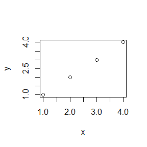

```r
x<-c(1,2,3,4)
y<-c(1,2,3,4)
plot(x,y)
```

```r
x<-c(1,2,3,4)
y<-c(1,2,3,4)
x1<-matrix(c(1,2,3,4,1,2,3,4),nrow=2,ncol=4,byrow=TRUE,dimnames=list(c("x","y"),c("1","2","3","4")))
knitr::kable(x1,format="markdown")
```

|  | 1 | 2 | 3 | 4 |
| --- | --- | --- | --- | --- |
| x | 1 | 2 | 3 | 4 |
| y | 1 | 2 | 3 | 4 |

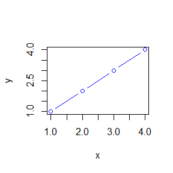

```r
plot(x,y,type="b",col="blue")
```

```r
knitr::kable(head(cars),format="markdown")
```

| speed | dist |
| --- | --- |
| 4 | 2 |
| 4 | 10 |
| 7 | 4 |
| 7 | 22 |
| 8 | 16 |
| 9 | 10 |

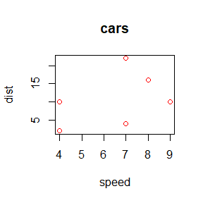

```r
plot(head(cars),type="p",col="red",main="cars")
```

## HW-2:

### Exersise 3.4

$$\begin{array}{l}{\text { 3.4 The Rayleigh density }[156, \text { Ch. } 18] \text { is }} \\ {\qquad f(x)=\frac{x}{\sigma^{2}} e^{-x^{2} /\left(2 \sigma^{2}\right)}, \quad x \geq 0, \sigma>0} \\ {\text { Develop an algorithm to generate random samples from a Rayleigh }(\sigma) \text { distri- }} \\ {\text { bution. Generate Rayleigh }(\sigma) \text { samples for several choices of } \sigma>0 \text { and check }} \\ {\text { that the mode of the generated samples is close to the theoretical mode } \sigma} \\ {\text { (check the histogram). }}\end{array}$$

### σ=0.5

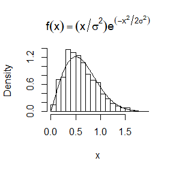

```r
n<-1000
sigma<-0.5#给σ赋值
u<-runif(n)#F(x)服从(0,1)上的均匀分布
x<-sqrt(-2*sigma^2*log(1-u,base=exp(1)))#对x取样
hist(x,prob=TRUE,breaks=25,main=expression(f(x)==(x/sigma^2)*e^(-x^2/2*sigma^2)))#画x的直方图
y<-seq(0,2,0.01)
lines(y,(y/sigma^2)*exp(-y^2/(2*sigma^2)))#画密度函数图像
```

### σ=1

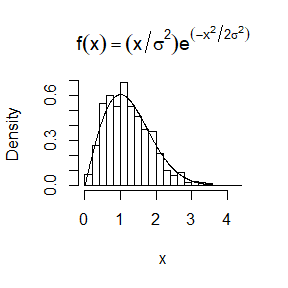

```r
n<-1000
sigma<-1#给σ赋值
u<-runif(n)#F(x)服从(0,1)上的均匀分布
x<-sqrt(-2*sigma^2*log(1-u,base=exp(1)))#对x取样
hist(x,prob=TRUE,breaks=25,main=expression(f(x)==(x/sigma^2)*e^(-x^2/2*sigma^2)))#画x的直方图
y<-seq(0,4,0.01)
lines(y,(y/sigma^2)*exp(-y^2/(2*sigma^2)))#画密度函数图像
```

### σ=1.2

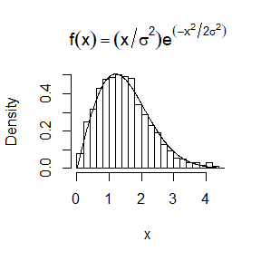

```r
n<-1000
sigma<-1.2#给σ赋值
u<-runif(n)#F(x)服从(0,1)上的均匀分布
x<-sqrt(-2*sigma^2*log(1-u,base=exp(1)))#对x取样
hist(x,prob=TRUE,breaks=25,main=expression(f(x)==(x/sigma^2)*e^(-x^2/2*sigma^2)))#画x的直方图
y<-seq(0,6,0.01)
lines(y,(y/sigma^2)*exp(-y^2/(2*sigma^2)))#画密度函数图像
```

### Discussion

#### From the figures,we can find that the lines fits well with the top of the histogram,which means the mode of the generated samples is close to the theoretical mode σ.So the inverse transform method is a good way to generate Rayleigh(σ) samples.However,there are still some cells on or under lines.That means our method can get improved.

### Exercise 3.11

$$\begin{equation}
\begin{array}{l}{\text { Generate a random sample of size } 1000 \text { from a normal location mixture. The }} \\ {\text { components of the mixture have } N(0,1) \text { and } N(3,1) \text { distributions with mixing }} \\ {\text { probabilities } p_{1} \text { and } p_{2}=1-p_{1} \text { . Graph the histogram of the sample with }} \\ {\text { density superimposed, for } p_{1}=0.75 . \text { Repeat with different values for } p_{1}} \\ {\text { and observe whether the empirical distribution of the mixture appears to be }} \\ {\text { bimodal. Make a conjecture about the values of } p_{1} \text { that produce bimodal }} \\ {\text { mixtures. }}\end{array}
\end{equation}$$

### p1=0.75,p2=0.25

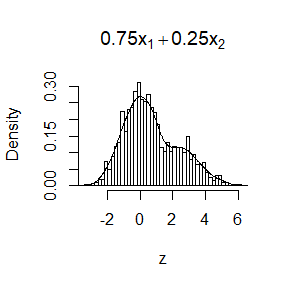

```r
n<-1000#样本容量
p<-c(0.25,0.75)#p1=0.75
x1<-rnorm(n,mean=0,sd=1)#对x1，x2取样
x2<-rnorm(n,mean=3,sd=1)
r<-sample(c(0,1),n,prob=p,replace=TRUE)#对混合概率取样
z<-r*x1+(1-r)*x2#混合分布
hist(z,prob=TRUE,breaks=50,main=expression(0.75*x[1]+0.25*x[2]))#画直方图
lines(density(z))#画密度图像
```

### p1=0.7,p2=0.3

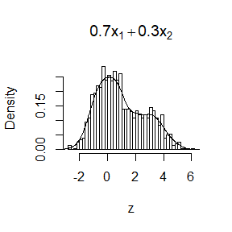

```r
n<-1000
p<-c(0.3,0.7)#p1=0.7
x1<-rnorm(n,mean=0,sd=1)
x2<-rnorm(n,mean=3,sd=1)
r<-sample(c(0,1),n,prob=p,replace=TRUE)
z<-r*x1+(1-r)*x2
hist(z,prob=TRUE,breaks=50,main=expression(0.7*x[1]+0.3*x[2]))
lines(density(z))
```

### p1=0.6,p2=0.4

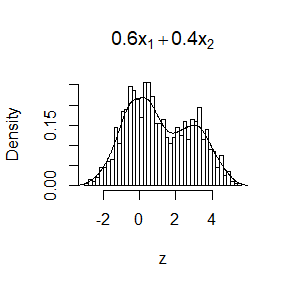

```r
n<-1000
p<-c(0.4,0.6)#p1=0.6
x1<-rnorm(n,mean=0,sd=1)
x2<-rnorm(n,mean=3,sd=1)
r<-sample(c(0,1),n,prob=p,replace=TRUE)
z<-r*x1+(1-r)*x2
hist(z,prob=TRUE,breaks=50,main=expression(0.6*x[1]+0.4*x[2]))
lines(density(z))
```

### p1=0.5,p2=0.5

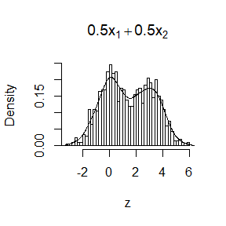

```r
n<-1000
p<-c(0.5,0.5)#p1=0.5
x1<-rnorm(n,mean=0,sd=1)
x2<-rnorm(n,mean=3,sd=1)
r<-sample(c(0,1),n,prob=p,replace=TRUE)
z<-r*x1+(1-r)*x2
hist(z,prob=TRUE,breaks=50,main=expression(0.5*x[1]+0.5*x[2]))
lines(density(z))
```

### p1=0.4,p2=0.6

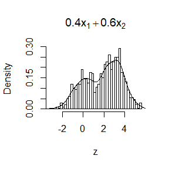

```r
n<-1000
p<-c(0.6,0.4)#p1=0.4
x1<-rnorm(n,mean=0,sd=1)
x2<-rnorm(n,mean=3,sd=1)
r<-sample(c(0,1),n,prob=p,replace=TRUE)
z<-r*x1+(1-r)*x2
hist(z,prob=TRUE,breaks=50,main=expression(0.4*x[1]+0.6*x[2]))
lines(density(z))
```

### Discussion

#### From the figures,we can find that the closer the p1 is to 0.5,the more obviously the empirical distribution of the mixture appears to be bimodal.Due to space constraints,we did not draw many figures with different mixing probabilities.So the data support of our conclutions might be not enough.

### Exercise 3.18

$$\begin{equation}
\begin{array}{l}{\text { Write a function to generate a random sample from a } W_{d}(\Sigma, n) \text { (Wishart) }} \\ {\text { distribution for } n>d+1 \geq 1 \text { , based on Bartlett's decomposition. }}\end{array}
\end{equation}$$

```r
sample.Wishart<-function(sigma,nf,d,N){
  #根据Bartlett分解对Wishart分布进行取样的函数
  #Σ是Wishart分布的协方差矩阵
  #nf是Wishart分布的自由度
  #d是正态分布的维度
  #N是样本容量
  L<-chol(sigma)# 计算Σ的Cholesky矩阵
  n<-1
  X<-as.list(numeric(N))
  for(n in 1:N){
    #对Wishart分布取样N次
    i<-1
    A<-matrix(numeric(d^2),nrow=d)
    c2<-numeric(d)
    for(i in 1:d){
      #对A矩阵对角元取样
      c2[i]<-rchisq(n=1,df=nf-i+1)
      A[i,i]<-sqrt(c2[i])
    }
    A
    i<-1
    j<-1
    for(i in 1:d){
      #对A其他元素取样
      for(j in 1:i){
      A[i,j]<rnorm(n=1)
      }
    }
    X[[n]]<-L%*%A%*%t(L)%*%t(A)#得到一个Wishart分布样本
  }
  return(X)#返回取样结果
}
#试运行Wishart取样函数
si<-matrix(c(1,2,3,2,1,2,3,2,1),nrow=3,byrow=TRUE)#任取3X3矩阵
sig<-si%*%t(si)#保证Σ是对称正定矩阵
#取自由度为5，维度为3，样本容量为5
n<-5
d<-3
N<-5
X<-sample.Wishart(sigma=sig,nf=n,d=d,N=N)#用Wishart取样函数取样
X
```

```
## [[1]]
##           [,1]     [,2]     [,3]
## [1,] 112.53973 54.95127 6.900418
## [2,]  35.33510 33.98168 5.413134
## [3,]  10.44883 12.74713 4.050818
##
## [[2]]
##           [,1]      [,2]     [,3]
## [1,] 465.03933 30.672014 2.299714
## [2,]  64.49173 18.360100 1.804044
## [3,]  15.58993  5.816419 1.350023
##
## [[3]]
##           [,1]     [,2]     [,3]
## [1,] 80.199107 60.13162 8.129718
## [2,] 28.868890 37.36827 6.377475
## [3,]  8.776286 14.34026 4.772465
##
## [[4]]
##          [,1]     [,2]      [,3]
## [1,] 90.79800 9.609519 10.605490
## [2,] 23.80561 6.882036  8.319631
## [3,] 13.38323 4.237958  6.225842
##
## [[5]]
##           [,1]     [,2]     [,3]
## [1,] 127.65609 51.73078 34.29770
## [2,]  47.78362 35.89861 26.90533
## [3,]  23.96980 20.35672 20.13411
```

### Discussion

#### Our method has been finished.However,we do not know how to evaluate our function.Does our function generate good samples?Do these samples obey Wishart distribution?Are there any other methods to generate samples from Wishart distribution?These are what we are interested in after the function finished.

## HW-3:

#### $$\begin{equation} \begin{array}{l}{\text { Compute a Monte Carlo estimate of }} \\ {\qquad \int_{0}^{\pi / 3} \sin t d t} \\ {\text { and compare your estimate with the exact value of the integral. }}\end{array} \end{equation}$$

### k=10,M=10000

```r
M<-10000#总样本容量
k<-10#分层数
r<-M/k#每层取样数
N<-50#重复估计的次数
T<-numeric(k)
est<-numeric(N)
g<-function(x)sin(x)*(x>0)*(x<(pi/3))
for(i in 1:N){
  for(j in 1:k)T[j]<-mean(g(runif(r,(j-1)*pi/(k*3),j*pi/(k*3))))
  est[i]<-mean(T)
}
mean<-mean(est)
s<-sd(est)
mean
```

```
## [1] 0.477464
```

```r
s
```

```
## [1] 0.0002382456
```

### k=100,M=100000

```r
M<-100000#总样本容量
k<-100#分层数
r<-M/k#每层取样数
N<-50#重复估计的次数
T<-numeric(k)
est<-numeric(N)
g<-function(x)sin(x)*(x>0)*(x<(pi/3))
for(i in 1:N){
  for(j in 1:k)T[j]<-mean(g(runif(r,(j-1)*pi/(k*3),j*pi/(k*3))))
  est[i]<-mean(T)
}
mean<-mean(est)
s<-sd(est)
mean
```

```
## [1] 0.4774646
```

```r
s
```

```
## [1] 7.926354e-06
```

### Discussion:After calculation, we know that the accurate value of the integral is 0.5. The result obtained by the Stratified sampling method is close to 0.5, and the variance is small enough. We choose the larger K and M, and find that we can only reduce the variance, not make the mean value closer to 0.5.

### $$\begin{equation} \begin{array}{l}{\text { Use Monte Carlo integration with antithetic variables to estimate }} \\ {\qquad \int_{0}^{1} \frac{e^{-x}}{1+x^{2}} d x} \\ {\text { and find the approximate reduction in variance as a percentage of the variance }} \\ {\text { without variance reduction. }}\end{array} \end{equation}$$

```r
k<-100#普通蒙特卡洛估计的样本容量
N<-50#重复估计的次数
T1<-numeric(k)
T2<-numeric(k/2)
est<-matrix(0,N,2)
g1<-function(x)exp(-x)/(1+x^2)*(x>0)*(x<1)#普通蒙特卡洛估计
g2<-function(x)(exp(-x)/(1+x^2)+exp(-(1-x))/(1+(1-x)^2))*(x>0)*(x<1)#对偶变量蒙特卡洛估计
for(i in 1:N){
  for(j in 1:k)T1[j]<-g1(runif(1,0,1))
  est[i,1]<-mean(T1)
  for(a in 1:(k/2))T2[a]<-g2(runif(1,0,1))
  est[i,2]<-sum(T2)/k
}
c(sd(est[,1]),sd(est[,2]),sd(est[,2])/sd(est[,1]))
```

```
## [1] 0.028971036 0.003893046 0.134377172
```

### $$\begin{equation} \begin{array}{l}{\text { Obtain the stratified importance sampling estimate in Example } 5.13 \text { and com- }} \\ {\text { pare it with the result of Example } 5.10 \text { . }}\end{array} \end{equation}$$

### $$\begin{equation} \begin{array}{l}{\text { Example } 5.13 \text { (Example } 5.10, \text { cont.) }} \\ {\text { In Example } 5.10 \text { our best result was obtained with importance function } f_{3}(x)=} \\ {e^{-x} /\left(1-e^{-1}\right), 0<x<1 . \text { From } 10000 \text { replicates we obtained the estimate }} \\ {\hat{\theta}=0.5257801 \text { and an estimated standard error } 0.0970314 \text { . Now divide the }} \\ {\text { interval }(0,1) \text { into five subintervals, }(j / 5,(j+1) / 5), j=0,1, \ldots, 4 \text { . }} \\ {\text { Then on the } j^{t h} \text { subinterval variables are generated from the density }} \\ {\qquad \frac{5 e^{-x}}{1-e^{-1}}, \quad \frac{j-1}{5}<x<\frac{j}{5} .} \\ {\text { The implementation is left as an exercise. }}\end{array} \end{equation}$$

```r
p<-c(0,0.2,0.4,0.6,0.8,1)
q<-numeric(6)
for(a in 1:6){
  #求f(x)5分位点
  q[a]<--log(1-p[a]*(1-exp(-1)))
}
M<-100#总样本容量
k<-5#分层数
r<-M/k#每层取样数
N<-50#重复估计的次数
T<-numeric(k)
est<-numeric(N)
for(i in 1:N){
  for(j in 1:5){
    u<-runif(r)#f3, inverse transform method
    x<--log(exp(-q[j])-u*((1-exp(-1))/5))
    gq<-function(x)exp(-x-log(1+x^2))
    fq<-function(x)(exp(-x)/(1-exp(-1)))
    fg<-gq(x)/(5*fq(x))
    T[j]<-mean(fg)#计算每个区间的积分估计值
  }
  est[i]<-sum(T)#对所有区间求和，得到整个区间的积分估计值
}
mean(est)
```

```
## [1] 0.5247838
```

```r
sd(est)
```

```
## [1] 0.002050875
```

### Discussion:The mean value of SI method is basically the same as that of example 5.10, but the variance is much smaller than that of example 5.10. It shows that stratified sampling can significantly reduce variance.

## HW-4:

#### Suppose a $95 \%$ symmetric $t$ -interval is applied to estimate a mean, but the sample data are non-normal. Then the probability the confidence interval covers the mean is not necessarily equal to $0.95 .$ Use a Monte Carlo experiment to estimate the coverage probability of the $t$ -interval for random samples of $\chi^{2}(2)$ data with sample size $n=20 .$ Compare your $t$ -interval results with the simulation results in Example 6.4. (The $t$ -interval should be more robust to departures from normality than the interval for variance.

```r
m<-1000#Monte Carlo estimation times
n<-20#sample size
up<-numeric(m)
down<-numeric(m)
mean<-numeric(m)
s<-numeric(m)
t<-qt(0.975,df=(n-1))
for(i in 1:m){
  x <- rchisq(n, df=2)
  mean[i]<-mean(x)
  s[i]<-var(x)
  up[i]<-(mean[i]+t*s[i]/sqrt(n))#up line of CI
  down[i]<-(mean[i]-t*s[i]/sqrt(n))#down line of CI
}
p<-mean(up>2&down<2)#compute the mean to get the confidence level
p
```

```
## [1] 0.948
```

```r
se<-sqrt((1-p)*p/m)#The standard error of the estimate
se
```

```
## [1] 0.007021111
```

### Discussion:The coverage probability is closer to 0.95.The standard error of the estimate is small enough.Our results are better than the results in Example 6.4.

#### Estimate the $0.025,0.05,0.95,$ and 0.975 quantiles of the skewness $\sqrt{b_{1}}$ under normality by a Monte Carlo experiment. Compute the standard error of the estimates from ( 2.14) using the normal approximation for the density (with exact variance formula). Compare the estimated quantiles with the quantiles of the large sample approximation $\sqrt{b_{1}} \approx N(0,6 / n)$

```r
m<-100#Monte Carlo estimation times
n<-200#sample size
N<-100#Number of repeated sampling
skew<-numeric(N)
p<-c(0.025,0.05,0.95,0.975)
q<-matrix(m*4,nrow=m,ncol=4)
for(i in 1:m){
  for(j in 1:N){
    x<-rnorm(n,mean=0,sd=1)#generate n samples from normal distribution
    skew[j]<-mean((x-mean(x))*3/(var(x))*(3/2))#compute skew of n samples
  }
  q[i,]<-quantile(skew,probs=p)#compute quantiles of N skew
}
quantile<-apply(q,2,mean)#the estimates of quantiles
quantile
```

```
## [1] -1.292783e-16 -1.135034e-16  1.154281e-16  1.323002e-16
```

```r
ql<-qnorm(p,mean=0,sd=sqrt(6/100000))#the quantiles of large sample approximation
ql
```

```
## [1] -0.01518182 -0.01274098  0.01274098  0.01518182
```

```r
f<-dnorm(quantile,mean=0,sd=sqrt(6/n))#the density of the normal distribution
v<-numeric(4)
for(a in 1:4){
  v[a]<-p[a]*(1-p[a])/(m*(f[a])^2)#The standard error of the estimate
}
v
```

```
## [1] 4.594579e-05 8.953539e-05 8.953539e-05 4.594579e-05
```

### Discussion:The result of Monte Carlo method is better than that of large sample approximation. The sample error is also small.

## HW-5:

#### Estimate the power of the skewness test of normality against symmetric Beta(α, α) distributions and comment on the results. Are the results different for heavy-tailed symmetric alternatives such as t(ν)?

#### Beta(α, α)

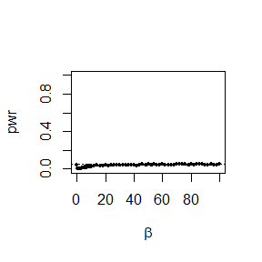

```r
set.seed(1234)
sk <- function(x) {
  #computes the sample skewness coeff.
  xbar <- mean(x)
  m3 <- mean((x - xbar)^3)
  m2 <- mean((x - xbar)^2)
  return( m3 / m2^1.5 )
}
alpha <- .05
n <- 30
m <- 2500
beta <- c(seq(0, 10, .5), seq(10, 100, 2))
N <- length(beta)
pwr <- numeric(N)
#critical value for the skewness test
cv <- qnorm(1-alpha/2, 0, sqrt(6*(n-2) / ((n+1)*(n+3))))
for (j in 1:N) { #for each epsilon
  b <- beta[j]
  sktests <- numeric(m)
  for (i in 1:m) { #for each replicate
    x <- rbeta(n, b, b)
    sktests[i] <- as.integer(abs(sk(x)) >= cv)
  }
  pwr[j] <- mean(sktests)
}
#plot power vs beta
plot(beta, pwr, type = "b",pch=19,cex=0.5,xlab = bquote(beta), ylim = c(0,1))
abline(h = alpha, lty = 3)
se <- sqrt(pwr * (1-pwr) / m) #add standard errors
lines(beta, pwr+se, lty = 3)
lines(beta, pwr-se, lty = 3)
```

#### Power has always been at a low level, indicating that the hypothesis test for beta distribution skewness is not good.

#### t(ν)

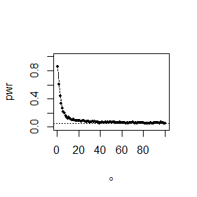

```r
set.seed(1234)
sk <- function(x) {
  #computes the sample skewness coeff.
  xbar <- mean(x)
  m3 <- mean((x - xbar)^3)
  m2 <- mean((x - xbar)^2)
  return( m3 / m2^1.5 )
}
alpha <- .05
n <- 30
m <- 2500
degree <- c(seq(1, 100, 1))
N <- length(degree)
pwr <- numeric(N)
#critical value for the skewness test
cv <- qnorm(1-alpha/2, 0, sqrt(6*(n-2) / ((n+1)*(n+3))))
for (j in 1:N) { #for each epsilon
  df <- degree[j]
  sktests <- numeric(m)
  for (i in 1:m) { #for each replicate
    x <- rt(n,df)
    sktests[i] <- as.integer(abs(sk(x)) >= cv)
  }
  pwr[j] <- mean(sktests)
}
#plot power vs degree
plot(degree, pwr, type = "b",pch=19,cex=0.5,xlab = bquote(degree), ylim = c(0,1))
abline(h = alpha, lty = 3)
se <- sqrt(pwr * (1-pwr) / m) #add standard errors
lines(degree, pwr+se, lty = 3)
lines(degree, pwr-se, lty = 3)
```

#### When the degree of freedom of t distribution is low, the value of power is large, which shows that the hypothesis test of skewness is good. However, with the increase of degrees of freedom, the power value gradually decreases, and finally maintains at a low level, which indicates that the hypothesis test effect of skewness is poor at this time.

#### Use Monte Carlo simulation to investigate whether the empirical Type I error rate of the t-test is approximately equal to the nominal significance level α, when the sampled population is non-normal. The t-test is robust to mild departures from normality. Discuss the simulation results for the cases where the sampled population is (i) χ2(1), (ii) Uniform(0,2), and (iii) Exponential(rate=1). In each case, test H0 : µ = µ0 vs H0 : µ =/ µ0, where µ0 is the mean of χ2(1), Uniform(0,2), and Exponential(1), respectively.

#### χ2(1)

```r
set.seed(1234)
alpha <- 0.05
miu <- 1 # Null hypothesis!
m <- 1e4
n <- 60
set.seed(123)
p.val1 <- numeric(m)
for(i in 1:m){
x<-rchisq(n,1)
hat<-sqrt(n)*(mean(x)-miu)
se<-var(x)
p.val1[i] <- 2*(1-pt(abs(hat/se),n-1)) # t-test p-value
}
print(c(mean(p.val1<=alpha),alpha))
```

```
## [1] 0.0702 0.0500
```

#### Uniform(0,2)

```r
set.seed(1234)
alpha <- 0.05
miu <- 1 # Null hypothesis!
m <- 1e4
n <- 60
set.seed(123)
p.val1 <- numeric(m)
for(i in 1:m){
x<-runif(n,min=0,max=2)
hat<-sqrt(n)*(mean(x)-miu)
se<-var(x)
p.val1[i] <- 2*(1-pt(abs(hat/se),n-1)) # t-test p-value
}
print(c(mean(p.val1<=alpha),alpha))
```

```
## [1] 0.2493 0.0500
```

#### Exponential(1)

```r
set.seed(1234)
alpha <- 0.05
miu <- 1 # Null hypothesis!
m <- 1e4
n <- 60
set.seed(123)
p.val1 <- numeric(m)
for(i in 1:m){
x<-rexp(n,rate=1)
hat<-sqrt(n)*(mean(x)-miu)
se<-var(x)
p.val1[i] <- 2*(1-pt(abs(hat/se),n-1)) # t-test p-value
}
print(c(mean(p.val1<=alpha),alpha))
```

```
## [1] 0.0936 0.0500
```

#### The Type I error rate of the three distribution mean tests is greater than the nominal confidence level. Chi square distribution is the closest, exponential distribution is the second, and uniform distribution is the worst. It shows that chi square distribution is the closest to normal distribution, and the difference between uniform distribution and normal distribution is the largest.

#### If we obtain the powers for two methods under a particular simulation setting with 10,000 experiments: say, 0.651 for one method and 0.676 for another method. Can we say the powers are diﬀerent at 0.05 level?

#### What is the corresponding hypothesis test problem?

#### What test should we use? Z-test, two-sample t-test, paired-t test or McNemar test?

#### What information is needed to test your hypothesis?

#### The corresponding hypothesis test problem is can we say the powers are diﬀerent at 0.05 level.The null hypothesis is there is no difference between the two methods at 0.05 level.

#### We should use McNemar test.Because McNemar test focuses on the differences between the two evaluation methods.

#### We need the powers for two methods, assuming p1 and p2 respectively. a=p1p2,b=p1(1-p2),c=p2(1-p1),d=(1-p1)(1-p2)。 The statistic is (b-c) ^ 2 / (b + c), which obeys the chi square distribution of degree of freedom 1.

## HW-6:

#### 7.6 Efron and Tibshirani discuss the scor (bootstrap) test score data on 88 students who took examinations in five subjects [84, Table 7.1], [188, Table 1.2.1].The first two tests (mechanics, vectors) were closed book and the last three tests (algebra, analysis, statistics) were open book. Each row of the data frame is a set of scores (xi1, . . . , xi5) for the ith student. Use a panel display to display the scatter plots for each pair of test scores. Compare the plot with the sample correlation matrix. Obtain bootstrap estimates of the standard errors for each of the following estimates: ˆ ρ12 = ˆ ρ(mec, vec), ˆ ρ34 = ˆ ρ(alg, ana), ˆ ρ35 = ˆ ρ(alg, sta), ˆ ρ45 = ˆ ρ(ana, sta).

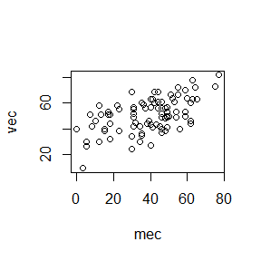

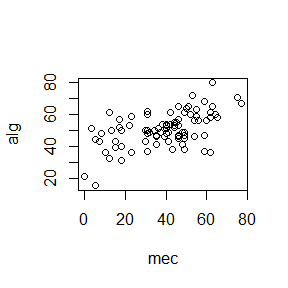

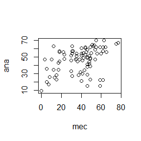

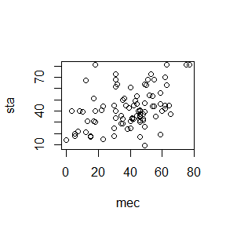

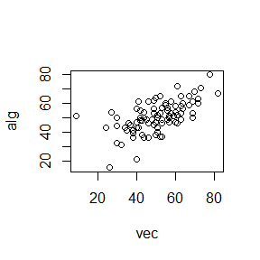

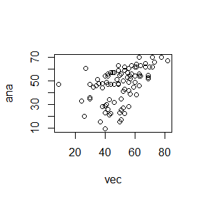

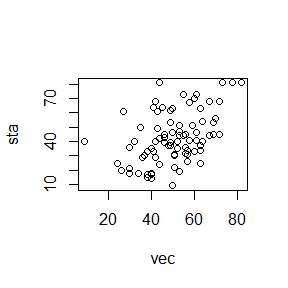

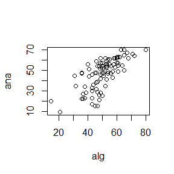

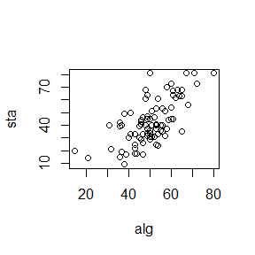

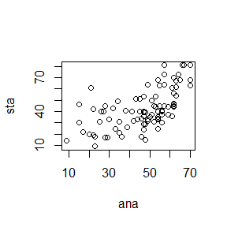

```r
set.seed(1234)
library(bootstrap)
score<-as.matrix(scor)
#display the scatter plots for each pair of test scores
for(i in 1:5){
  for(j in 1:5){
    if(j>i) plot(score[,i],score[,j],xlab=colnames(score)[i],ylab=colnames(score)[j])
  }
}
```

```r
#compute the sample correlation matrix
cor<-as.matrix(cor(score))
cor
```

```
##           mec       vec       alg       ana       sta
## mec 1.0000000 0.5534052 0.5467511 0.4093920 0.3890993
## vec 0.5534052 1.0000000 0.6096447 0.4850813 0.4364487
## alg 0.5467511 0.6096447 1.0000000 0.7108059 0.6647357
## ana 0.4093920 0.4850813 0.7108059 1.0000000 0.6071743
## sta 0.3890993 0.4364487 0.6647357 0.6071743 1.0000000
```

```r
#function to obtain bootstrap estimates of correlation
cor.b<-function(x,y,B){
  n<-length(x)
  corstar<-numeric(B)
  for(i in 1:B){
    xstar<-sample(x,n,replace=TRUE)
    ystar<-sample(y,n,replace=TRUE)
    corstar[i]<-cor(xstar,ystar)
  }
  return(corstar)
}
B<-100
cor12.b<-cor.b(score[,1],score[,2],B)
cor34.b<-cor.b(score[,3],score[,4],B)
cor35.b<-cor.b(score[,3],score[,5],B)
cor45.b<-cor.b(score[,4],score[,5],B)
SE<-matrix(c(sd(cor12.b),sd(cor34.b),sd(cor35.b),sd(cor45.b)),nrow=1,ncol=4,byrow=TRUE,dimnames=list(c("SE"),c("SE12.b","SE34.b","SE35.b","SE45.b")))
SE
```

```
##        SE12.b    SE34.b     SE35.b    SE45.b
## SE 0.09429456 0.1174883 0.09752036 0.1067267
```

#### The more the center points of the scatter plot gather around the line, the greater the correlation coefficient of the two variables. The more dispersed the point, the smaller the correlation coefficient. Bootstrap estimates of the standard errors are near 0.1.

#### 7.B Repeat Project 7.A for the sample skewness statistic. Compare the coverage rates for normal populations (skewness 0) and χ2(5) distributions (positive skewness).

```r
set.seed(1234)
#computes the sample skewness coeff.
sk<-function(x) {
  xbar <- mean(x)
  m3 <- mean((x - xbar)^3)
  m2 <- mean((x - xbar)^2)
  return( m3 / m2^1.5 )
}
#normal populations
alpha<-0.05
M<-100
B<-100
n<-2000
sk.star<-numeric(B)
se<-up<-down<-numeric(M)

#estimate the coverage probabilities of the standard normal bootstrap confidence interval
for(i in 1:M){
  xhat<-rnorm(n,mean=0,sd=1)
  sk.hat<-sk(xhat)
  for(j in 1:B){
    xstar<-sample(xhat,n,replace=TRUE)
    sk.star[j]<-sk(xstar)
  }
  se[i]<-sd(sk.star)
  up[i]<-(sk.hat-qnorm(alpha/2,mean=0,sd=1)*se[i])
  down[i]<-(sk.hat-qnorm(1-alpha/2,mean=0,sd=1)*se[i])
}
CP.s<-mean(down<0&up>0)
s.left<-mean(down>0)
s.right<-mean(up<0)
#estimate the coverage probabilities of the basic bootstrap confidence interval
for(i in 1:M){
  xhat<-rnorm(n,mean=0,sd=1)
  sk.hat<-sk(xhat)
  for(j in 1:B){
    xstar<-sample(xhat,n,replace=TRUE)
    sk.star[j]<-sk(xstar)
  }
  up[i]<-(2*sk.hat-quantile(sk.star,probs=alpha/2))
  down[i]<-(2*sk.hat-quantile(sk.star,probs=(1-alpha/2)))
}
CP.b<-mean(down<0&up>0)
b.left<-mean(down>0)
b.right<-mean(up<0)
#estimate the coverage probabilities of the percentile confidence interval
for(i in 1:M){
  xhat<-rnorm(n,mean=0,sd=1)
  sk.hat<-sk(xhat)
  for(j in 1:B){
    xstar<-sample(xhat,n,replace=TRUE)
    sk.star[j]<-sk(xstar)
  }
  up[i]<-quantile(sk.star,probs=(1-alpha/2))
  down[i]<-quantile(sk.star,probs=alpha/2)
}
CP.p<-mean(down<0&up>0)
p.left<-mean(down>0)
p.right<-mean(up<0)

norm<-matrix(c(CP.s,s.left,s.right,CP.b,b.left,b.right,CP.p,p.left,p.right),nrow=1,ncol=9)

#χ2(5) distributions
sk1<-sqrt(8/5)
sk.star<-numeric(B)
se<-up<-down<-numeric(M)

#estimate the coverage probabilities of the standard normal bootstrap confidence interval
for(i in 1:M){
  xhat<-rchisq(n,df=5)
  sk.hat<-sk(xhat)
  for(j in 1:B){
    xstar<-sample(xhat,n,replace=TRUE)
    sk.star[j]<-sk(xstar)
  }
  se[i]<-sd(sk.star)
  up[i]<-(sk.hat-qnorm(alpha/2,mean=0,sd=1)*se[i])
  down[i]<-(sk.hat-qnorm(1-alpha/2,mean=0,sd=1)*se[i])
}
CP.s<-mean(down<sk1&up>sk1)
s.left<-mean(down>sk1)
s.right<-mean(up<sk1)

#estimate the coverage probabilities of the basic bootstrap confidence interval
for(i in 1:M){
  xhat<-rchisq(n,df=5)
  sk.hat<-sk(xhat)
  for(j in 1:B){
    xstar<-sample(xhat,n,replace=TRUE)
    sk.star[j]<-sk(xstar)
  }
  up[i]<-(2*sk.hat-quantile(sk.star,probs=alpha/2))
  down[i]<-(2*sk.hat-quantile(sk.star,probs=(1-alpha/2)))
}
CP.b<-mean(down<sk1&up>sk1)
b.left<-mean(down>sk1)
b.right<-mean(up<sk1)

#estimate the coverage probabilities of the percentile confidence interval
for(i in 1:M){
  xhat<-rchisq(n,df=5)
  sk.hat<-sk(xhat)
  for(j in 1:B){
    xstar<-sample(xhat,n,replace=TRUE)
    sk.star[j]<-sk(xstar)
  }
  up[i]<-quantile(sk.star,probs=(1-alpha/2))
  down[i]<-quantile(sk.star,probs=alpha/2)
}
CP.p<-mean(down<sk1&up>sk1)
p.left<-mean(down>sk1)
p.right<-mean(up<sk1)

chisq<-matrix(c(CP.s,s.left,s.right,CP.b,b.left,b.right,CP.p,p.left,p.right),nrow=1,ncol=9)
compare<-matrix(c(norm,chisq),nrow=2,ncol=9,byrow=TRUE,dimnames=list(c("norm","chisq"),c("CP.standard","standard.left","standard.right","CP.basic","basic.left","basic.right","CP.percentile","percentile.left","percentile.right")))
compare
```

```
##       CP.standard standard.left standard.right CP.basic basic.left
## norm         0.94          0.05           0.01     0.92       0.05
## chisq        0.91          0.01           0.08     0.86       0.01
##       basic.right CP.percentile percentile.left percentile.right
## norm         0.03          0.96            0.03             0.01
## chisq        0.13          0.91            0.01             0.08
```

## HW-7:

#### Exercise 7.8:Refer to Exercise 7.7. Obtain the jackknife estimates of bias and standard error of θˆ.

```r
set.seed(1234)
library(bootstrap)
scor<-as.matrix(scor)
lamda<-eigen(cor(scor))$values
theta.hat<-lamda[1]/sum(lamda)
J<-nrow(scor)
theta.jack<-numeric(J)
for(i in 1:J){
  #obtain the jackknife estimates of theta
  scor.hat<-scor[-i,]
  n<-nrow(scor.hat)
  sigma.MLE<-((n-1)/n)*cor(scor.hat)
  lamda.hat<-eigen(sigma.MLE)$values
  theta.jack[i]<-lamda.hat[1]/sum(lamda.hat)
}
#Obtain the jackknife estimates of bias and standard error
bias.jack<-(J-1)*(mean(theta.jack)-theta.hat)
sd.jack<-sqrt((J-1)*mean((theta.jack-theta.hat)^2))
round(c(bias.jack=bias.jack,sd.jack=sd.jack),2)
```

```
## bias.jack   sd.jack
##      0.00      0.04
```

#### Discussion: The jackknife estimates of bias is zero.The jackknife estimates of standard error is close to zero.

#### Exercise 7.10: In Example 7.18, leave-one-out (n-fold) cross validation was used to select the best fitting model. Repeat the analysis replacing the Log-Log model with a cubic polynomial model. Which of the four models is selected by the cross validation procedure? Which model is selected according to maximum adjusted R^2?

```r
set.seed(1234)
library(DAAG)
attach(ironslag)
ybar<-mean(magnetic)
n<-length(magnetic) #in DAAG ironslag
e1<-e2<-e3<-e4<-numeric(n)
# for n-fold cross validation
# fit models on leave-one-out samples
for(k in 1:n){
  y<-magnetic[-k]
  x<-chemical[-k]

  J1<-lm(y~x)
  yhat1<-J1$coef[1]+J1$coef[2]*chemical[k]
  e1[k]<-magnetic[k]-yhat1

  J2<-lm(y~x+I(x^2))
  yhat2<-J2$coef[1]+J2$coef[2]*chemical[k]+J2$coef[3]*chemical[k]^2
  e2[k]<-magnetic[k]-yhat2

  J3<-lm(log(y)~x)
  logyhat3<-J3$coef[1]+J3$coef[2]*chemical[k]
  yhat3<-exp(logyhat3)
  e3[k]<-magnetic[k]-yhat3

  J4<-lm(y~x+I(x^2)+I(x^3))
  yhat4<-J4$coef[1]+J4$coef[2]*chemical[k]+J4$coef[3]*chemical[k]^2+J4$coef[4]*chemical[k]^3
  e4[k]<-magnetic[k]-yhat4
}
round(c(MSE1=mean(e1^2),MSE2=mean(e2^2),MSE3=mean(e3^2),MSE4=mean(e4^2)),4)
```

```
##    MSE1    MSE2    MSE3    MSE4
## 19.5564 17.8525 18.4419 18.1776
```

```r
#adjusted R^2
SSE1<-SSE2<-SSE3<-SSE4<-numeric(n)
SST<-sum((magnetic-ybar)^2)

M1<-lm(magnetic~chemical)
yhat1<-M1$coef[1]+M1$coef[2]*chemical
SSE1<-sum((yhat1-magnetic)^2)
R1<-(1-SSE1*(n-1)/(SST*(n-1-1)))

M2<-lm(magnetic~chemical+I(chemical^2))
yhat2<-M2$coef[1]+M2$coef[2]*chemical+M2$coef[3]*chemical^2
SSE2<-sum((yhat2-magnetic)^2)
R2<-(1-SSE2*(n-1)/(SST*(n-2-1)))

M3<-lm(log(magnetic)~chemical)
logyhat3<-M3$coef[1]+M3$coef[2]*chemical
yhat3<-exp(logyhat3)
SSE3<-sum((yhat3-magnetic)^2)
R3<-(1-SSE3*(n-1)/(SST*(n-1-1)))

M4<-lm(magnetic~chemical+I(chemical^2)+I(chemical^3))
yhat4<-M4$coef[1]+M4$coef[2]*chemical+M4$coef[3]*chemical^2+M4$coef[4]*chemical^3
SSE4<-sum((yhat4-magnetic)^2)
R4<-(1-SSE4*(n-1)/(SST*(n-3-1)))

round(c(adjusted.R1=R1,adjusted.R2=R2,adjusted.R3=R3,adjusted.R4=R4),4)
```

```
## adjusted.R1 adjusted.R2 adjusted.R3 adjusted.R4
##      0.5282      0.5768      0.5522      0.5740
```

#### Discussion: Since the second model has the least MSE, the second model would be selected by the CV procedure.Besides, the second model also has the biggest adjusted R^2.It would be selected according to maximun adjusted R^2.

## HW-8:

#### 8.3

The Count 5 test for equal variances in Section 6.4 is based on the maximum number of extreme points. Example 6.15 shows that the Count 5 criterion is not applicable for unequal sample sizes. Implement a permutation test for equal variance based on the maximum number of extreme points that applies when sample sizes are not necessarily equal.

```r
set.seed(1234)
count5<-function(x1,x2){
  R<-1000
  T1<-T2<-numeric(R)
  z<-c(x1,x2)
  n<-length(z)
  K<-1:n
  n1<-length(x1)
  for(i in 1:R){
    k<-sample(K,n1,replace=FALSE)
    x1.star<-z[k]
    x2.star<-z[-k]
    T1[i]<-sum(x1.star>max(x1))+sum(x1.star<min(x1))
    T2[i]<-sum(x2.star>max(x2))+sum(x2.star<min(x2))
  }
  p1<-(1+sum(T1>=5))/(1+R)
  p2<-(1+sum(T2>=5))/(1+R)
  return(round(c(p1=p1,p2=p2),3))
}
x1<-rnorm(10,0,3)
x2<-rnorm(20,0,3)
alpha<-0.05
p<-max(count5(x1,x2))
if(p>=alpha) sprintf("p-value is %.3f.At the %.2f confidence level, the variances of two samples are different",p,alpha)
if(p<alpha) sprintf("p-value is %.3f.At the %.2f confidence level, the variances of two samples are equal",p,alpha)
```

```
## [1] "p-value is 0.001.At the 0.05 confidence level, the variances of two samples are equal"
```

```r
x1<-rnorm(10,0,1)
x2<-rnorm(20,0,3)
alpha<-0.05
p<-max(count5(x1,x2))
if(p>=alpha) sprintf("p-value is %.3f.At the %.2f confidence level, the variances of two samples are different",p,alpha)
```

```
## [1] "p-value is 0.447.At the 0.05 confidence level, the variances of two samples are different"
```

```r
if(p<alpha) sprintf("p-value is %.3f.At the %.2f confidence level, the variances of two samples are equal",p,alpha)
```

#### The results show that our method can test whether the sample variances of different samples whose sizes are different are the same.

#### slides

Power comparison (distance correlation test versus ball covariance test)

Model1: $Y=X/4+e$

Model2: $Y=X/4\times e$

$X\sim N(0_2,I_2)$, $e\sim N(0_2,I_2)$, $X$ and $e$ are independent.

use the method like the slides.

```r
dCov<-function(x, y){
  x<-as.matrix(x)
  y<-as.matrix(y)
  n<-nrow(x)
  m<-nrow(y)
  if(n!=m||n<2) stop("Sample sizes must agree")
  if(!(all(is.finite(c(x, y))))) stop("Data contains missing or infinite values")
  Akl<-function(x){
    d<-as.matrix(dist(x))
    m<-rowMeans(d)
    M<-mean(d)
    a<-sweep(d,1,m)
    b<-sweep(a,2,m)
    return(b+M)
  }
  A<-Akl(x)
  B<-Akl(y)
  return(sqrt(mean(A*B)))
}
ndCov2<-function(z,ix,dims){
#dims contains dimensions of x and y
  p<-dims[1]
  q<-dims[2]
  d<-p+q
  x<-z[,1:p]#leave x as is
  y<-z[ix,-(1:p)]#permute rows of y
  return(nrow(z)*dCov(x, y)^2)
}
library("boot")
```

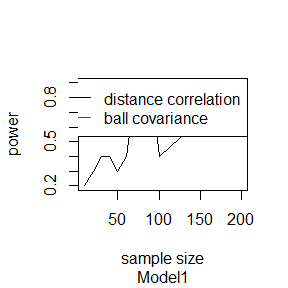

```r
library("Ball")
set.seed(12345)
m<-10
R<-100
alpha<-0.05
size<-c(10,20,30,40,50,60,70,80,90,100,200)
b<-length(size)
pow1<-pow2<-matrix(NA,b,2)
for(j in 1:b){
  p.values1<-p.values2<-matrix(NA,m,2)
  for(i in 1:m){
    x<-matrix(rnorm(size[j]*2),ncol=2)
    e<-matrix(rnorm(size[j]*2),ncol=2)
    y1<-x/4+e
    y2<-(x/4)*e
    z1<-cbind(x,y1)
    z2<-cbind(x,y2)
    boot.obj1<-boot(data=z1,statistic=ndCov2,R=R,sim="permutation",dims=c(2,2))
    #permutatin:resampling without replacement
    p.values1[i,1]<-mean(boot.obj1$t>=boot.obj1$t0)
    p.values1[i,2]<-bd.test(x=x,y=y1,R=R,seed=j*i*123)$p.value
    boot.obj2<-boot(data=z2,statistic=ndCov2,R=R,sim="permutation",dims=c(2,2))
    #permutatin:resampling without replacement
    p.values2[i,1]<-mean(boot.obj2$t>=boot.obj2$t0)
    p.values2[i,2]<-bd.test(x=x,y=y2,R=R,seed=j*i*123)$p.value
  }
  pow1[j,1]<-mean(p.values1[,1]<alpha)
  pow1[j,2]<-mean(p.values1[,2]<alpha)
  pow2[j,1]<-mean(p.values2[,1]<alpha)
  pow2[j,2]<-mean(p.values2[,2]<alpha)
}
plot(size,pow1[,1],sub="Model1",xlab="sample size",ylab="power",type="l",col=1)
lines(size,pow1[,2],type="l",col=2)
legend('topright',legend=c('distance correlation','ball covariance'),col=1:2,lty=c(1,1))
```

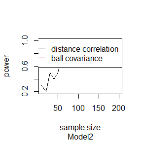

```r
plot(size,pow2[,1],sub="Model2",xlab="sample size",ylab="power",type="l",col=1)
lines(size,pow2[,2],type="l",col=2)
legend('topright',legend=c('distance correlation','ball covariance'),col=1:2,lty=c(1,1))
```

#### The power value of ball test in model one is very small, almost 0. The power value of ball test in model two is always 1. The distance test of both models changes with the change of sample size, and the overall trend is increasing.

#### Although the result is not good, I have tried my best. I really don’t know what’s wrong. I hope the students who are correcting the homework will be merciful. Can help me find out the problem, thank you!

## HW-9:

#### Exercise 9.4: Implement a random walk Metropolis sampler for generating the standard Laplace distribution (see Exercise 3.2). For the increment, simulate from a normal distribution. Compare the chains generated when different variances are used for the proposal distribution. Also, compute the acceptance rates of each chain.

```r
L.d<-function(x){
  f<-(exp(-abs(x)))/2
  return(f)
}
L.Metropolis<-function(sigma,N){
  x<-numeric(N)
  x[1]<-rnorm(1,0,sigma)
  u<-runif(N)
  r<-0
  a<-0
  for(i in 2:N){
    y<-rnorm(1,x[i-1],sigma)
    fy<-L.d(y)
    fx<-L.d(x[i-1])
    if (u[i]<=fy/fx){
      x[i]<-y
      a<-a+1
    }
    else {
      x[i]<-x[i-1]
      r<-r+1
    }
  }
  a.rate<-a/N
return(list(x=x,r=r,a.rate=a.rate))
}
library("GeneralizedHyperbolic")
set.seed(123)
N<-2000
sigma<-c(5, 10, 15, 20)
L1<-L.Metropolis(sigma[1],N)
L2<-L.Metropolis(sigma[2],N)
L3<-L.Metropolis(sigma[3],N)
L4<-L.Metropolis(sigma[4],N)
#number of candidate points rejected
round(c(reject.1=L1$r,reject.2=L2$r,reject.3=L3$r,reject.4=L4$r))
```

```
## reject.1 reject.2 reject.3 reject.4
##     1427     1694     1755     1841
```

```r
#acceptance rate
round(c(acceptance.rate1=L1$a.rate,acceptance.rate2=L2$a.rate,acceptance.rate3=L3$a.rate,acceptance.rate4=L4$a.rate),4)
```

```
## acceptance.rate1 acceptance.rate2 acceptance.rate3 acceptance.rate4
##           0.2860           0.1525           0.1220           0.0790
```

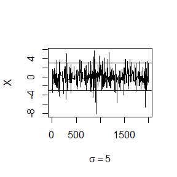

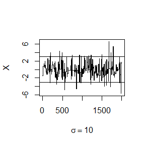

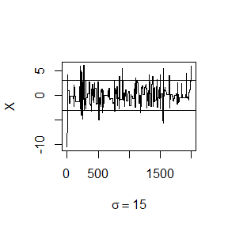

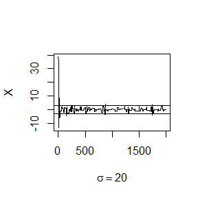

```r
refline<-qskewlap(c(0.025,0.975))
L<-cbind(L1$x,L2$x,L3$x,L4$x)
for (j in 1:4) {
  plot(L[,j],type="l",xlab=bquote(sigma==.(round(sigma[j],3))),ylab="X",ylim=range(L[,j]))
  abline(h=refline)
}
```

```r
par(mfrow=c(1,1)) #reset to default

p<-c(.05,seq(.1, .9, .1),.95)
Q<-qskewlap(p)
L<-cbind(L1$x,L2$x,L3$x,L4$x)
mc<-L[501:N, ]
QL<-apply(mc,2,function(x) quantile(x, p))


Qc<-matrix(round(cbind(Q,QL),3),nrow=11,ncol=5,dimnames=list(c("5%","10%","20%","30%","40%","50%","60%","70%","80%","90%","95%"),c("origin","5","10","15","20")))
knitr::kable(Qc,format="markdown")
```

|  | origin | 5 | 10 | 15 | 20 |
| --- | --- | --- | --- | --- | --- |
| 5% | -2.303 | -2.300 | -2.384 | -2.292 | -1.696 |
| 10% | -1.609 | -1.639 | -1.771 | -1.659 | -1.141 |
| 20% | -0.916 | -0.941 | -1.142 | -0.941 | -0.900 |
| 30% | -0.511 | -0.500 | -0.709 | -0.655 | -0.473 |
| 40% | -0.223 | -0.220 | -0.346 | -0.464 | -0.214 |
| 50% | 0.000 | 0.031 | -0.186 | -0.050 | -0.041 |
| 60% | 0.223 | 0.240 | 0.011 | 0.181 | 0.156 |
| 70% | 0.511 | 0.496 | 0.270 | 0.395 | 0.294 |
| 80% | 0.916 | 0.918 | 0.779 | 1.083 | 0.585 |
| 90% | 1.609 | 1.511 | 1.526 | 2.085 | 1.528 |
| 95% | 2.303 | 2.419 | 2.298 | 2.826 | 2.003 |

#### Judging from the acceptance rate, the conditions are satisfied when the variance is 5 and 10, and the larger the variance load, the lower the acceptance rate. From the image, the performance is best when the variance is 15. From the quantile point of view, when the variance is 5, it is closest to the original quantile. In summary, it can be seen that the variance changes have a greater impact on the results.

## HW-10:

### Exercise 11.1

```r
x<-0.1
isTRUE(log(exp(x))==exp(log(x)))
```

```
## [1] FALSE
```

```r
isTRUE(all.equal(log(exp(x)),exp(log(x))))
```

```
## [1] TRUE
```

```r
identical(log(exp(x)),exp(log(x)))
```

```
## [1] FALSE
```

### Exercise 11.5

```r
f<-function(k,a){
  ck<-sqrt((a^2*k)/(k+1-a^2))
  f1<-2*gamma((k+1)/2)/(sqrt(pi*k)*gamma(k/2))
  f2<-function(u){
    (1+u^2/k)^(-(k+1)/2)
  }
  inte<-integrate(f2,lower=0,upper=ck,rel.tol=.Machine$double.eps^0.25)
  return(f1*inte$value)
}
findroot<-function(k){
  a<-seq(0,sqrt(k),length.out=50*k)
  n<-length(a)
  b<-numeric(n-2)
  for(i in 2:(n-1)){
    b[i]<-abs(f(k-1,a[i])-f(k,a[i]))
  }
  if(min(b)<=0.001){
    i<-which(b==min(b),arr.ind=TRUE)
    return(a[i+1])
  }
  else return(a[1])
}
k<-c(4:25,100)
N<-length(k)
a.root<-numeric(N)
for(j in 1:N){
  a.root[j]<-findroot(k[j])
}
a.root
```

```
##  [1] 0.010050251 0.008980193 0.008192273 0.007580949 0.007088790
##  [6] 0.006681514 0.006337230 0.006041211 0.005783141 0.005555549
## [11] 0.005352872 0.005170872 0.005006258 0.004856426 0.004719289
## [16] 0.004593150 0.004476613 0.004368518 0.004267894 0.004173918
## [21] 0.004085888 0.004003203 0.002000400
```

```r
#points A(k) in 11.4
s<-function(k,a){
  ck<-sqrt((a^2*k)/(k+1-a^2))
  return(1-pt(ck,k))
}
sroot<-function(k){
  a<-seq(0,sqrt(k),length.out=50*k)
  n<-length(a)
  b<-numeric(n-2)
  for(i in 2:(n-1)){
    b[i]<-abs(s(k-1,a[i])-s(k,a[i]))
  }
  if(min(b)<=0.001){
    i<-which(b==min(b),arr.ind=TRUE)
    return(a[i+1])
  }
  else return(a[1])
}
s.root<-numeric(N)
j<-1
for(j in 1:N){
  s.root[j]<-sroot(k[j])
}
s.root
```

```
##  [1] 0.010050251 0.008980193 0.008192273 0.007580949 0.007088790
##  [6] 0.006681514 0.006337230 0.006041211 0.005783141 0.005555549
## [11] 0.005352872 0.005170872 0.005006258 0.004856426 0.004719289
## [16] 0.004593150 0.004476613 0.004368518 0.004267894 0.004173918
## [21] 0.004085888 0.004003203 0.002000400
```

#### There is no difference between the solutions with the points A(k) in exercise 11.4.

#### A-B-O blood type problem

```r
library(nloptr)
# Mle
eval_f0 = function(x,x1,n.A=28,n.B=24,nOO=41,nAB=70) {

  r1 = 1-sum(x1)
  nAA = n.A*x1[1]^2/(x1[1]^2+2*x1[1]*r1)
  nBB = n.B*x1[2]^2/(x1[2]^2+2*x1[2]*r1)
  r = 1-sum(x)
  return(-2*nAA*log(x[1])-2*nBB*log(x[2])-2*nOO*log(r)-
           (n.A-nAA)*log(2*x[1]*r)-(n.B-nBB)*log(2*x[2]*r)-nAB*log(2*x[1]*x[2]))
}


# constraint
eval_g0 = function(x,x1,n.A=28,n.B=24,nOO=41,nAB=70) {
  return(sum(x)-0.999999)
}

opts = list("algorithm"="NLOPT_LN_COBYLA",
             "xtol_rel"=1.0e-8)
mle = NULL
r = matrix(0,1,2)
r = rbind(r,c(0.2,0.35))# the beginning value of p0 and q0
j = 2
while (sum(abs(r[j,]-r[j-1,]))>1e-8) {
res = nloptr( x0=c(0.3,0.25),
               eval_f=eval_f0,
               lb = c(0,0), ub = c(1,1),
               eval_g_ineq = eval_g0,
               opts = opts, x1=r[j,],n.A=28,n.B=24,nOO=41,nAB=70 )
j = j+1
r = rbind(r,res$solution)
mle = c(mle,eval_f0(x=r[j,],x1=r[j-1,]))
}
#the result of EM algorithm
r
```

```
##            [,1]      [,2]
##  [1,] 0.0000000 0.0000000
##  [2,] 0.2000000 0.3500000
##  [3,] 0.3162298 0.3089571
##  [4,] 0.3260961 0.3098301
##  [5,] 0.3271807 0.3103186
##  [6,] 0.3273212 0.3104097
##  [7,] 0.3273409 0.3104241
##  [8,] 0.3273438 0.3104263
##  [9,] 0.3273442 0.3104266
## [10,] 0.3273442 0.3104267
## [11,] 0.3273442 0.3104267
## [12,] 0.3273442 0.3104267
```

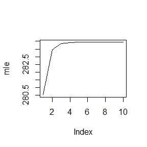

```r
#the max likelihood values
plot(mle,type = 'l')
```

## HW-11:

```r
formulas<-list(mpg~disp,mpg~I(1/disp),mpg~disp+wt,mpg~I(1/disp)+wt)
fun<-function(i){
  lm(formulas[[i]],data=mtcars)
}
lapply(1:4,fun)
```

```
## [[1]]
##
## Call:
## lm(formula = formulas[[i]], data = mtcars)
##
## Coefficients:
## (Intercept)         disp
##    29.59985     -0.04122
##
##
## [[2]]
##
## Call:
## lm(formula = formulas[[i]], data = mtcars)
##
## Coefficients:
## (Intercept)    I(1/disp)
##       10.75      1557.67
##
##
## [[3]]
##
## Call:
## lm(formula = formulas[[i]], data = mtcars)
##
## Coefficients:
## (Intercept)         disp           wt
##    34.96055     -0.01772     -3.35083
##
##
## [[4]]
##
## Call:
## lm(formula = formulas[[i]], data = mtcars)
##
## Coefficients:
## (Intercept)    I(1/disp)           wt
##      19.024     1142.560       -1.798
```

```r
lm<-list(NULL)
length(lm)<-4
for(i in 1:4){
  lm[[i]]<-fun(i)
}
lm
```

```
## [[1]]
##
## Call:
## lm(formula = formulas[[i]], data = mtcars)
##
## Coefficients:
## (Intercept)         disp
##    29.59985     -0.04122
##
##
## [[2]]
##
## Call:
## lm(formula = formulas[[i]], data = mtcars)
##
## Coefficients:
## (Intercept)    I(1/disp)
##       10.75      1557.67
##
##
## [[3]]
##
## Call:
## lm(formula = formulas[[i]], data = mtcars)
##
## Coefficients:
## (Intercept)         disp           wt
##    34.96055     -0.01772     -3.35083
##
##
## [[4]]
##
## Call:
## lm(formula = formulas[[i]], data = mtcars)
##
## Coefficients:
## (Intercept)    I(1/disp)           wt
##      19.024     1142.560       -1.798
```

#### We find the results of lapply() are same with the results of loops.

```r
boot<-function(x) x[sample(nrow(x),replace=TRUE),]
boot_lm<-function(i){
  dat<-boot(mtcars)
  lm(mpg~disp,data=dat)
}
lapply(1:10,boot_lm)
```

```
## [[1]]
##
## Call:
## lm(formula = mpg ~ disp, data = dat)
##
## Coefficients:
## (Intercept)         disp
##    27.04354     -0.03356
##
##
## [[2]]
##
## Call:
## lm(formula = mpg ~ disp, data = dat)
##
## Coefficients:
## (Intercept)         disp
##    28.89343     -0.03604
##
##
## [[3]]
##
## Call:
## lm(formula = mpg ~ disp, data = dat)
##
## Coefficients:
## (Intercept)         disp
##    30.39959     -0.04616
##
##
## [[4]]
##
## Call:
## lm(formula = mpg ~ disp, data = dat)
##
## Coefficients:
## (Intercept)         disp
##    28.07849     -0.03258
##
##
```

[output cut: 43 more lines]

```
## lm(formula = mpg ~ disp, data = dat)
##
## Coefficients:
## (Intercept)         disp
##    28.13801     -0.03619
##
##
## [[10]]
##
## Call:
## lm(formula = mpg ~ disp, data = dat)
##
## Coefficients:
## (Intercept)         disp
##    31.43950     -0.04328
```

```r
b<-list(NULL)
length(b)<-10
for(j in 1:10){
  b[[j]]<-boot_lm(j)
}
b
```

```
## [[1]]
##
## Call:
## lm(formula = mpg ~ disp, data = dat)
##
## Coefficients:
## (Intercept)         disp
##    30.51785     -0.04491
##
##
## [[2]]
##
## Call:
## lm(formula = mpg ~ disp, data = dat)
##
## Coefficients:
## (Intercept)         disp
##    29.68553     -0.04118
##
##
## [[3]]
##
## Call:
## lm(formula = mpg ~ disp, data = dat)
##
## Coefficients:
## (Intercept)         disp
##    27.94343     -0.03382
##
##
## [[4]]
##
## Call:
## lm(formula = mpg ~ disp, data = dat)
##
## Coefficients:
## (Intercept)         disp
##    31.03424     -0.04423
##
##
```

[output cut: 43 more lines]

```
## lm(formula = mpg ~ disp, data = dat)
##
## Coefficients:
## (Intercept)         disp
##    28.18801     -0.03735
##
##
## [[10]]
##
## Call:
## lm(formula = mpg ~ disp, data = dat)
##
## Coefficients:
## (Intercept)         disp
##     28.7383      -0.0392
```

####
$$\begin{array}{l}{\text { 5. For each model in the previous two exercises, extract } R^{2} \text { using }} \\ {\text { the function below. }} \\ {\text { rsq }<\text { - function (mod) sumary (mod) } \$ \text { r. squared }}\end{array}$$

```r
rsq<-function(i) summary(fun(i))$r.squared
lapply(1:4,rsq)
```

```
## [[1]]
## [1] 0.7183433
##
## [[2]]
## [1] 0.8596865
##
## [[3]]
## [1] 0.7809306
##
## [[4]]
## [1] 0.8838038
```

```r
boot_rsq<-function(i){
  summary(boot_lm(i))$r.squared
}
lapply(1:10,boot_rsq)
```

```
## [[1]]
## [1] 0.7635986
##
## [[2]]
## [1] 0.7802576
##
## [[3]]
## [1] 0.7348501
##
## [[4]]
## [1] 0.7164578
##
## [[5]]
## [1] 0.7428305
##
## [[6]]
## [1] 0.7033184
##
## [[7]]
## [1] 0.6739633
##
## [[8]]
## [1] 0.7013801
##
## [[9]]
## [1] 0.7310196
##
## [[10]]
## [1] 0.7602624
```

####
$$\begin{array}{l}{\text { 3. The following code simulates the performance of a t-test for }} \\ {\text { non-normal data. Use sapply() and an anonymous function }} \\ {\text { to extract the p-value from every trial. }} \\ {\text { trials }<-\text { replicater }} \\ { \text { t.test(rpois }(10,10), \text { rpois(7, } 10))} \\ {\text { Extra challenge: get rid of the anonymous function by using }} \\ {\text { I: directly. }}\end{array}$$

```r
trials<-replicate(100,t.test(rpois(10,10),rpois(7,10)),simplify=FALSE)
p<-function(i) trials[[i]]$p.value
sapply(1:100,p)
```

```
##   [1] 0.96771107 0.93530887 0.79933650 0.32049383 0.63930895 0.50144785
##   [7] 0.47416893 0.94734442 0.80809124 0.64536049 0.21717677 0.14386179
##  [13] 0.38815934 0.74565094 0.38893472 0.03193888 0.84928758 0.09267732
##  [19] 1.00000000 0.98546044 0.14694742 0.69823218 0.93510288 0.48529568
##  [25] 0.89108545 0.47649092 0.68913753 0.39839397 0.22208839 0.34596609
##  [31] 0.66995770 0.26190057 0.79377952 0.36294917 0.10346800 0.83554416
##  [37] 0.96348321 0.55808678 0.15038132 0.69378223 0.83178558 0.28326050
##  [43] 0.17345956 0.18456838 0.22872806 0.95967859 0.69321529 0.40517731
##  [49] 0.62344777 0.53678958 0.97030522 0.15515085 0.87116063 0.48181433
##  [55] 0.53513914 0.65677152 0.43747133 0.30293741 0.65065396 0.61840931
##  [61] 0.75148567 0.55457607 0.81194810 0.85369042 0.97560066 0.17934925
##  [67] 0.49566084 0.39929428 0.61938166 0.81712877 0.52724026 0.41476662
##  [73] 0.50249784 0.51137699 0.29377546 0.93708622 0.36407856 0.52196272
##  [79] 0.84433091 0.77050556 0.76011688 0.13038435 0.61573233 0.47746908
##  [85] 0.04008025 0.77211574 0.07755771 0.24375595 0.19792885 0.67957621
##  [91] 0.04499309 0.74147709 0.42002509 1.00000000 0.78909699 0.20893392
##  [97] 0.29352079 0.70490912 0.18363736 0.86545194
```

####
$$\begin{array}{l}{\text { 7. Implement mesapply(), a multicore version of sapply(). Can }} \\ {\text { you implement mcvapply(), a parallel version of vapply(O? }} \\ {\text { Why or why not? }}\end{array}$$

```r
library(parallel)
boot.rsq<-function(i){
  dat<-mtcars[sample(nrow(mtcars),replace=TRUE),]
  lm<-lm(mpg~disp,data=dat)
  summary(lm)$r.squared
}
no_cores<-7
cl<-makeCluster(no_cores)
system.time(sapply(1:100,boot.rsq))
```

```
## 用户 系统 流逝
## 0.09 0.00 0.09
```

```r
system.time(parSapply(cl,1:100,boot.rsq))
```

```
## 用户 系统 流逝
## 0.00 0.00 0.03
```

```r
system.time(vapply(1:100,boot.rsq,0))
```

```
## 用户 系统 流逝
##  0.1  0.0  0.1
```

```r
stopCluster(cl)
```

#### We found that parSapply saves time compared to sapply. But windows system cannot use mcvapply. I also had problems using the teacher’s method, and I planned to ask the teacher in class.

## HW-12:

You have already written an R function for Exercise 9.4 (page 277, Statistical Computing with R). Rewrite an Rcpp function for the same task. Compare the generated random numbers by the two functions using qqplot. Campare the computation time of the two functions with microbenchmark. Comments your results.

```r
set.seed(12345)

#the function using R
lap_f = function(x) exp(-abs(x))

rw.Metropolis = function(sigma, x0, N){
 x = numeric(N)
 x[1] = x0
 u = runif(N)
 k = 0
 for (i in 2:N) {
  y = rnorm(1, x[i-1], sigma)
  if (u[i] <= (lap_f(y) / lap_f(x[i-1]))) x[i] = y
  else {
  x[i] = x[i-1]
  k = k+1
  }
 }
 return(list(x = x, k = k))
}

#the function using Rcpp
library(Rcpp)
```

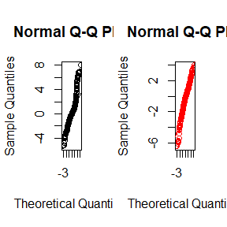

```r
cppFunction('NumericVector cpp_Metropolis(double sigma, double x0, int N){
NumericVector x(N);
x[0]=x0;
for (int i=1;i<N;i++) {
double e=runif(1)[0];
double z=rnorm(1,x[i-1],sigma)[0];
if (e<=exp(abs(x[i-1])-abs(z))) x[i]=z;
else {
x[i]=x[i-1];
}
}
return x;
}')

#generate random numbers
N<-1000
sigma<-1
x0<-0
R<-rw.Metropolis(sigma,x0,N)$x
cpp<-cpp_Metropolis(sigma,x0,N)

#qqplot
par(mfrow=c(1,2))
qqnorm(R)
qqline(R)
qqnorm(cpp,col="red")
qqline(cpp,col="red")
```

```r
#computation time
library(microbenchmark)
time<-microbenchmark(R=rw.Metropolis(sigma,x0,N),Rcpp=cpp_Metropolis(sigma,x0,N))
summary(time)[,c(1,3,5,6)]
```

```
##   expr      lq  median      uq
## 1    R 2523.45 2791.15 3031.30
## 2 Rcpp  135.85  146.95  158.15
```

The qq plot of Rcpp data is closer to the diagonal, and the results are more consistent with the original data. And use Rcpp operation to save time.